# Microbenchmark: Architectural Justification

- Show All Code
- Hide All Code
- View Source

Performance analysis of list-of-data.frames design for Chromatograms

Author

Philippine Louail

Published

September 25, 2026

## System Information

```r
cat("CPU Cores:", parallel::detectCores(), "\n")
```

```
CPU Cores: 20
```

```r
cat("R Version:", R.version$version.string, "\n")
```

```
R Version: R version 4.6.0 (2026-04-24 ucrt)
```

```r
cat("Platform:", R.version$platform, "\n")
```

```
Platform: x86_64-w64-mingw32
```

```r
if (requireNamespace("Chromatograms", quietly = TRUE)) {
  cat("Chromatograms Version:",
      as.character(packageVersion("Chromatograms")), "\n")
}
```

```
Chromatograms Version: 1.3.2
```

## Motivation

The `Chromatograms` package stores chromatographic peaks data as a list of `data.frame`s — one per chromatogram — rather than a single large matrix. This analysis provides empirical justification for that design choice.

Chromatographic analysis (peak picking, integration, smoothing, similarity scoring) operates primarily on vectors of intensity or retention time within a single chromatogram. The alternative matrix layout would optimize for cross-chromatogram comparisons at the cost of the far more frequent single-chromatogram operations.

We benchmark:

1. Columnar access — extracting the intensity vector from a single chromatogram (the dominant operation).
2. Row access — extracting a single data point across all variables (rare in practice).
3. Scaling behaviour — how the advantage holds as chromatogram length grows.

## Overview: Measurement Scales

All timing measurements in this document use nanoseconds (ns) for reporting, which is appropriate for per-operation latencies in the microsecond to nanosecond range. Memory measurements use megabytes (MB) for practical discussion of object footprints.

```r
library(microbenchmark)
library(data.table)
library(dplyr)
library(tidyr)
library(ggplot2)
```

## 1. Basic Column Access Benchmark

We simulate a single chromatogram of typical length (1 000 data points) stored as either a matrix, a data.frame, or a data.table, then measure columnar extraction.

```r
set.seed(42)
n_rows <- 1000L

# Matrix representation
mat <- matrix(runif(n_rows * 2), ncol = 2)
colnames(mat) <- c("rtime", "intensity")

# data.frame representation (what Chromatograms uses)
df <- data.frame(rtime = runif(n_rows), intensity = runif(n_rows))

# data.table representation
dt <- as.data.table(df)

mb_basic <- microbenchmark(
  matrix_col_name   = mat[, "intensity"],
  matrix_col_index  = mat[, 2L],
  df_dollar         = df$intensity,
  df_bracket        = df[["intensity"]],
  dt_dollar         = dt$intensity,
  dt_bracket        = dt[["intensity"]],
  times = 10000L,
  unit = "nanoseconds"
)

mb_basic
```

```
Unit: nanoseconds
             expr  min   lq      mean median   uq     max neval
  matrix_col_name 3000 3301 6285.1033   3500 4100 4272801 10000
 matrix_col_index 2900 3202 5337.0856   3401 4201 3707601 10000
        df_dollar  600  801  954.5269    900 1000   25102 10000
       df_bracket 3800 4201 4958.3592   4301 4601  125802 10000
        dt_dollar  700  901 1117.5981   1001 1101  170501 10000
       dt_bracket 3900 4400 5190.3413   4501 4801  217601 10000
```

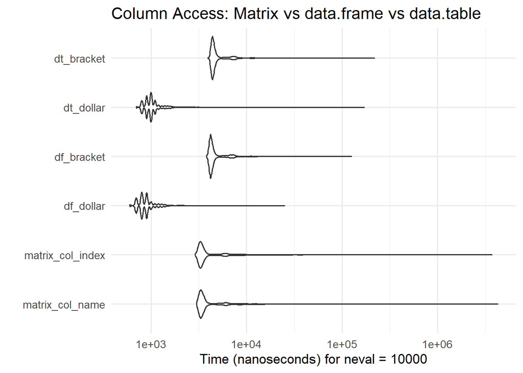

Figure 1: Column access latency: matrix vs data.frame vs data.table (1 000 rows)

```r
autoplot(mb_basic) +
  labs(
    x = "Time (ns)", y = NULL,
    title = "Column Access: Matrix vs data.frame vs data.table"
  ) +
  theme_minimal(base_size = 13)
```

```r
## Medians of this run and the storage-layout ratio quoted in the thesis:
## named matrix column extraction relative to data.frame `$` access.
med_basic <- sapply(split(mb_basic$time, mb_basic$expr), median)
knitr::kable(
  data.frame(accessor = names(med_basic), median_ns = med_basic,
             relative_to_df_dollar = med_basic / med_basic[["df_dollar"]]),
  digits = 2, row.names = FALSE,
  caption = "Column access, 1 000 rows: medians of this run (ns)")
```

Column access, 1 000 rows: medians of this run (ns)

| accessor | median_ns | relative_to_df_dollar |
| --- | --- | --- |
| matrix_col_name | 3500 | 3.89 |
| matrix_col_index | 3401 | 3.78 |
| df_dollar | 900 | 1.00 |
| df_bracket | 4301 | 4.78 |
| dt_dollar | 1001 | 1.11 |
| dt_bracket | 4501 | 5.00 |

```r
cat(sprintf("Storage-layout ratio (matrix_col_name / df_dollar): %.2f\n",
            med_basic[["matrix_col_name"]] / med_basic[["df_dollar"]]))
```

```
Storage-layout ratio (matrix_col_name / df_dollar): 3.89
```

### Interpretation

The results show an advantage for data.frame column access via the $ operator (median ≈ 900 ns) compared to named matrix column extraction (median ≈ 3,500 ns) — a 3.9× speedup. Bracket-based data.frame access (df[[“col”]], median ≈ 4,300 ns) performs similarly to matrix indexing, confirming that the speedup is specific to the $ operator. Internally, $ bypasses dimension checking and performs a direct list-element lookup on the underlying data.frame structure, whereas mat[, “col”] must resolve dimension names, validate indices, and allocate a result vector.

data.table $ access performs comparably to data.frame $ access, since data.table inherits from data.frame and the $ operator follows the same list-element lookup path. The bracket accessor dt[[“col”]] likewise performs similarly to df[[“col”]]. This confirms that data.table does not provide an additional columnar access advantage over data.frame for this simple extraction pattern — both benefit from the same underlying list structure.

Since chromatographic workflows access rtime and intensity columns thousands of times during peak detection and integration, this constant-factor advantage over matrices accumulates.

## 2. Row Access Benchmark

For completeness, we also benchmark row access — extracting a single scan across all variables. This is the operation where matrices traditionally excel, but it is rarely needed in chromatographic workflows.

```r
mb_row <- microbenchmark(
  matrix_row = mat[500L, ],
  df_row     = df[500L, ],
  dt_row     = dt[500L, ],
  times = 10000L,
  unit = "nanoseconds"
)

mb_row
```

```
Unit: nanoseconds
       expr   min    lq       mean median     uq     max neval
 matrix_row   500   800   1232.386    902   1201   59900 10000
     df_row 21301 22701  31234.161  24701  31001 4688801 10000
     dt_row 76501 83401 109327.458  88602 108501 5886501 10000
```

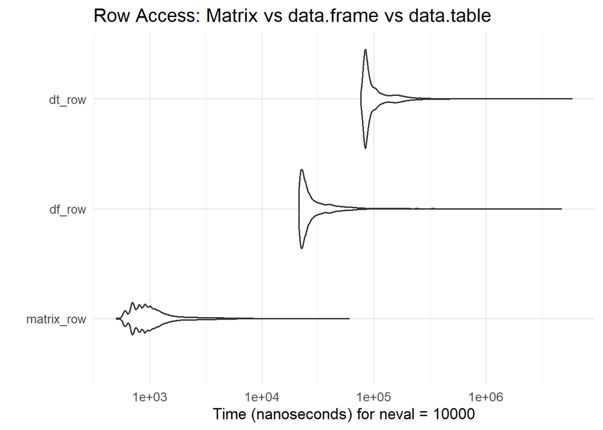

Figure 2: Row access latency: matrix vs data.frame vs data.table

```r
autoplot(mb_row) +
  labs(
    x = "Time (ns)", y = NULL,
    title = "Row Access: Matrix vs data.frame vs data.table"
  ) +
  theme_minimal(base_size = 13)
```

### Interpretation

Matrix row access (median ≈ 900 ns) is substantially faster than data.frame row access (median ≈ 24,700 ns) — roughly 27.4× faster. This is because a matrix stores all values in a single contiguous memory block, so extracting a row is a simple pointer-offset calculation. In contrast, a data.frame row slice must extract one element from each column list and assemble them into a new data.frame. data.table row access (median ≈ 88,600 ns) is slower still than data.frame row access, because the data.table `[` method adds argument-processing overhead on top of the same column-oriented internal storage.

However, this trade-off is deliberate. Chromatographic analysis pipelines rarely need cross-variable row access. Operations such as peak detection, integration, FWHM estimation, and similarity scoring all work on vectors of intensity or rtime. The only scenario where row access might be relevant is extracting a single scan point across multiple channels, which is uncommon. Optimizing for the dominant access pattern (columnar) at the cost of the rare pattern (row-based) is therefore the correct engineering decision.

## 3. Scaling Behaviour

How does the column-access advantage scale with chromatogram length?

```r
sizes <- c(100, 500, 1000, 5000, 10000, 50000)

scaling_results <- lapply(sizes, function(n) {
  m <- matrix(runif(n * 2), ncol = 2)
  colnames(m) <- c("rtime", "intensity")
  d <- data.frame(rtime = m[, 1], intensity = m[, 2])
  dtb <- as.data.table(d)

  mb <- microbenchmark(
    matrix     = m[, "intensity"],
    df         = d$intensity,
    data.table = dtb$intensity,
    times  = 5000L,
    unit   = "nanoseconds"
  )

  mb |>
    as.data.frame() |>
    mutate(n_points = n)
})

scaling_df <- bind_rows(scaling_results)
```

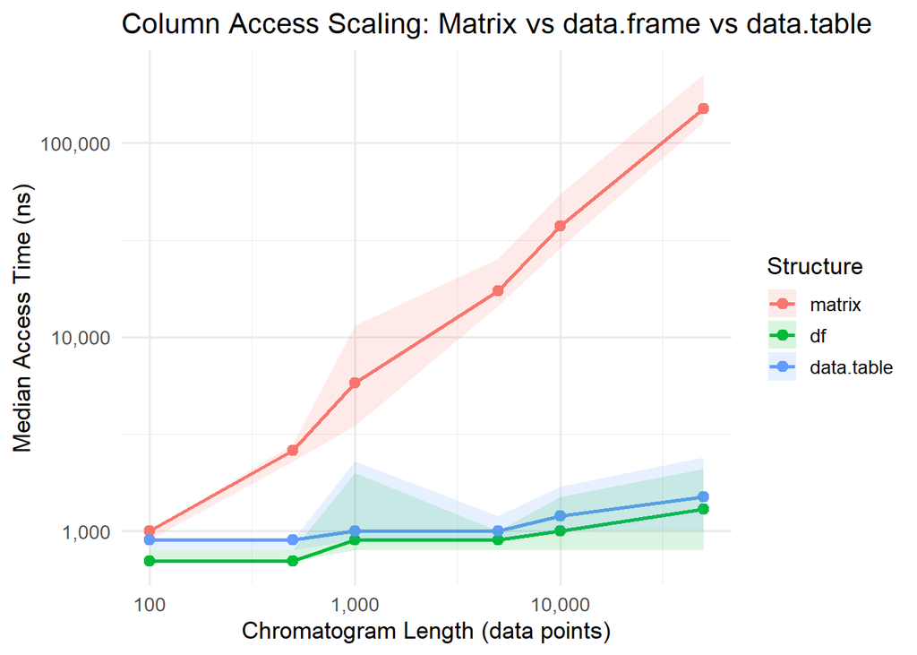

Figure 3: Column access time vs chromatogram length

```r
scaling_summary <- scaling_df |>
  group_by(expr, n_points) |>
  summarise(
    median_ns = median(time),
    q25 = quantile(time, 0.25),
    q75 = quantile(time, 0.75),
    .groups = "drop"
  )

ggplot(scaling_summary, aes(x = n_points, y = median_ns, colour = expr)) +
  geom_line(linewidth = 1) +
  geom_point(size = 2.5) +
  geom_ribbon(aes(ymin = q25, ymax = q75, fill = expr), alpha = 0.15,
              colour = NA) +
  scale_x_log10(labels = scales::comma) +
  scale_y_log10(labels = scales::comma) +
  labs(
    x = "Chromatogram Length (data points)",
    y = "Median Access Time (ns)",
    colour = "Structure",
    fill = "Structure",
    title = "Column Access Scaling: Matrix vs data.frame vs data.table"
  ) +
  theme_minimal(base_size = 13)
```

```r
scaling_summary |>
  select(expr, n_points, median_ns) |>
  pivot_wider(names_from = expr, values_from = median_ns) |>
  mutate(
    speedup_df = matrix / df,
    speedup_dt = matrix / data.table
  ) |>
  knitr::kable(
    digits = 1,
    col.names = c("N points", "Matrix (ns)", "data.frame (ns)",
                  "data.table (ns)", "Speedup df (×)", "Speedup dt (×)"),
    caption = "Column access speedup over matrix"
  )
```

Column access speedup over matrix

| N points | Matrix (ns) | data.frame (ns) | data.table (ns) | Speedup df (×) | Speedup dt (×) |
| --- | --- | --- | --- | --- | --- |
| 100 | 1001 | 701 | 901 | 1.4 | 1.1 |
| 500 | 2601 | 702 | 901 | 3.7 | 2.9 |
| 1000 | 5800 | 901 | 1002 | 6.4 | 5.8 |
| 5000 | 17401 | 900 | 1001 | 19.3 | 17.4 |
| 10000 | 37401 | 1001 | 1201 | 37.4 | 31.1 |
| 50000 | 150301 | 1301 | 1502 | 115.5 | 100.1 |

### Interpretation

The scaling results demonstrate that the data.frame column access time is essentially constant regardless of the number of rows (≈ 700–1,300 ns across all sizes), while matrix column extraction time grows linearly with chromatogram length (from ≈ 1,000 ns at 100 points to ≈ 150,300 ns at 50 000 points).

This is because $ returns a reference to the existing column vector without copying, whereas mat[, col] must allocate a new vector and copy the selected column from the contiguous matrix memory block. As chromatogram length increases, the copy cost grows proportionally.

The practical implication is significant: at 5 000 data points (typical for UHPLC data), data.frame access is 19.3× faster; at 50 000 points (common for high-resolution full-scan MS data), the speedup reaches 115.5×. This means the data.frame design becomes more advantageous precisely for the high-resolution data where performance matters most.

## 4. List of data.frames vs data.tables vs Matrices (Realistic Scenario)

In a real Chromatograms object, we store many chromatograms as a list. The realistic design question is: should each element be a data.frame (with named columns rtime, intensity), a data.table, or a 2-column matrix?

We compare these three plausible designs for the dominant operation — extracting the intensity vector of a single chromatogram from the collection.

```r
n_chrom <- 1000L
n_pts   <- 1000L

# List of data.frames (actual Chromatograms design)
list_df <- lapply(seq_len(n_chrom), function(i) {
  data.frame(
    rtime     = sort(runif(n_pts, 0, 600)),
    intensity = abs(rnorm(n_pts, mean = 1000, sd = 500))
  )
})

# List of matrices (plausible alternative)
list_mat <- lapply(list_df, function(d) {
  m <- as.matrix(d)
  colnames(m) <- c("rtime", "intensity")
  m
})

# List of data.tables (plausible alternative)
list_dt <- lapply(list_df, as.data.table)

mb_realistic <- microbenchmark(
  list_df_dollar    = list_df[[500]]$intensity,
  list_df_bracket   = list_df[[500]][["intensity"]],
  list_dt_dollar    = list_dt[[500]]$intensity,
  list_dt_bracket   = list_dt[[500]][["intensity"]],
  list_mat_name     = list_mat[[500]][, "intensity"],
  list_mat_index    = list_mat[[500]][, 2L],
  times = 10000L,
  unit = "nanoseconds"
)

mb_realistic
```

```
Unit: nanoseconds
            expr  min   lq     mean median   uq     max neval
  list_df_dollar  700 1001 1559.513   1301 1701  399701 10000
 list_df_bracket 4000 4601 6972.096   6100 7501  358601 10000
  list_dt_dollar  800 1102 1704.276   1501 1901  175201 10000
 list_dt_bracket 4201 4801 7189.152   6201 7801  322301 10000
   list_mat_name 3100 3800 7515.994   4901 6102 7306901 10000
  list_mat_index 3100 3701 6891.992   4801 6100 4586801 10000
```

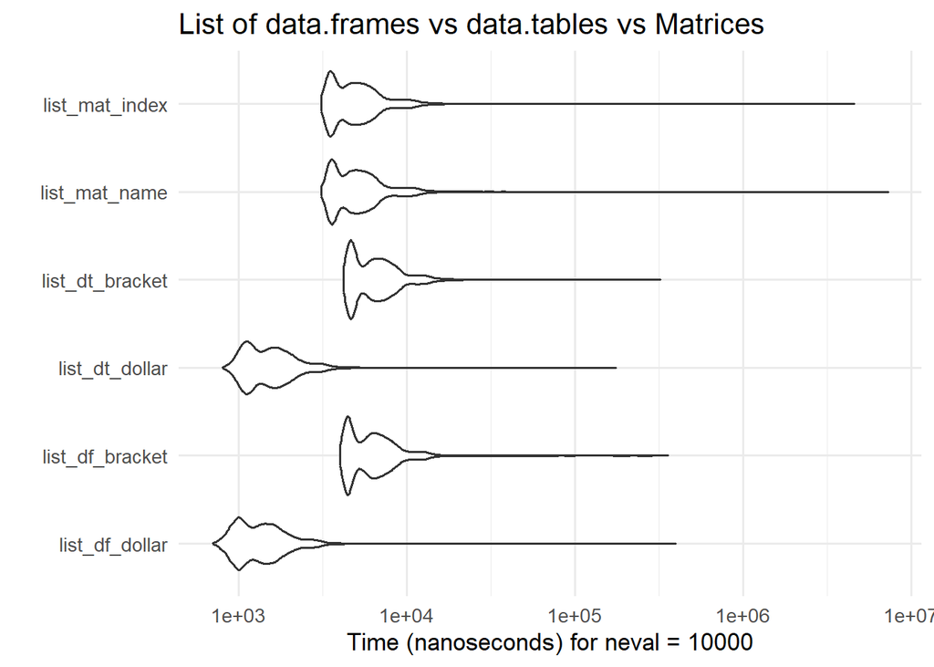

Figure 4: Accessing intensity of one chromatogram from a collection of 1 000

```r
autoplot(mb_realistic) +
  labs(
    x = "Time (ns)", y = NULL,
    title = "List of data.frames vs data.tables vs Matrices"
  ) +
  theme_minimal(base_size = 13)
```

```r
med_real <- sapply(split(mb_realistic$time, mb_realistic$expr), median)
knitr::kable(
  data.frame(accessor = names(med_real), median_ns = med_real,
             relative_to_list_df_dollar = med_real / med_real[["list_df_dollar"]]),
  digits = 2, row.names = FALSE,
  caption = "One chromatogram from a list of 1 000: medians of this run (ns)")
```

One chromatogram from a list of 1 000: medians of this run (ns)

| accessor | median_ns | relative_to_list_df_dollar |
| --- | --- | --- |
| list_df_dollar | 1301 | 1.00 |
| list_df_bracket | 6100 | 4.69 |
| list_dt_dollar | 1501 | 1.15 |
| list_dt_bracket | 6201 | 4.77 |
| list_mat_name | 4901 | 3.77 |
| list_mat_index | 4801 | 3.69 |

### Interpretation

Even in a realistic list-based scenario with 1 000 chromatograms, data.frame $ access (median ≈ 1,300 ns) remains the fastest approach — 3.7× faster than the best matrix accessor (mat[, 2] by integer index, median ≈ 4,800 ns) and 3.8× faster than named matrix access (mat[, “intensity”], median ≈ 4,900 ns). data.table $ access performs comparably to data.frame $ access, confirming that the list-element lookup mechanism is shared. Bracket-based access for both data.frame and data.table performs comparably to matrix indexing, confirming that the advantage is specific to the $ operator.

This benchmark is the most directly relevant to the Chromatograms package design, since it mirrors the actual storage layout: a list of per-chromatogram containers. The results confirm that the list-of-data.frames architecture provides consistently faster columnar access than a list-of-matrices, while data.table offers no additional advantage for this access pattern. Since data.table adds dependency weight without a performance benefit for per-chromatogram column extraction, the data.frame choice is the most parsimonious.

## 5. Memory Overhead Comparison

The list-of-data.frames representation also has implications for memory. Notably, it supports variable-length chromatograms without padding, which is critical for real data where chromatograms span different RT ranges. We compare the memory footprint of list-of-data.frames vs list-of-matrices for both fixed-length and variable-length chromatograms.

```r
# Variable-length chromatograms (realistic)
set.seed(42)
var_list_df <- lapply(seq_len(n_chrom), function(i) {
  n <- sample(200:2000, 1)
  data.frame(
    rtime     = sort(runif(n, 0, 600)),
    intensity = abs(rnorm(n, 1000, 500))
  )
})

var_list_mat <- lapply(var_list_df, function(d) {
  m <- as.matrix(d)
  colnames(m) <- c("rtime", "intensity")
  m
})

var_list_dt <- lapply(var_list_df, as.data.table)

# List of data.tables (fixed-length, from earlier)
list_dt_fixed <- lapply(list_df, as.data.table)

get_size_mb <- function(x) {
  as.numeric(object.size(x)) / 1024^2
}

memory_df <- data.frame(
  Scenario = c("Fixed-length (1 000 × 1 000 pts)",
               "Variable-length (1 000 × 200–2 000 pts)"),
  `data.frame (MB)` = round(c(get_size_mb(list_df),
                               get_size_mb(var_list_df)), 1),
  `data.table (MB)` = round(c(get_size_mb(list_dt_fixed),
                               get_size_mb(var_list_dt)), 1),
  `matrix (MB)` = round(c(get_size_mb(list_mat),
                           get_size_mb(var_list_mat)), 1),
  check.names = FALSE
)

knitr::kable(
  memory_df,
  caption = "Memory footprint comparison across storage representations"
)
```

Memory footprint comparison across storage representations

| Scenario | data.frame (MB) | data.table (MB) | matrix (MB) |
| --- | --- | --- | --- |
| Fixed-length (1 000 × 1 000 pts) | 16.1 | 16.6 | 15.8 |
| Variable-length (1 000 × 200–2 000 pts) | 18.0 | 18.5 | 17.8 |

### Interpretation

The memory comparison shows that data.frame and data.table overhead relative to matrices is negligible in practice — all three list-based representations have comparable footprints. The small overhead arises from per-element metadata (column names, row names, class attributes) stored once per chromatogram — a constant cost dwarfed by the actual data vectors. data.table’s additional internal attributes (e.g., `.internal.selfref`) add a marginal cost that is not meaningfully different at this scale.

Crucially, none of the list-based representations require padding. A single large matrix storing all chromatograms would need every row to have the same number of columns, forcing shorter chromatograms to be padded with NA values. For a dataset where chromatogram lengths vary from 200 to 2 000 points, padding would inflate memory usage substantially. The list-of-data.frames design avoids this waste entirely while paying virtually no overhead compared to list-of-matrices or list-of-data.tables.

## Conclusion

The benchmarks confirm that the list-of-data.frames design is well suited for the Chromatograms package. The `$` accessor provides 1.4–115.5× faster column extraction than matrices (scaling with chromatogram length), while data.table offers no additional speed advantage since both share the same list-element lookup. Memory overhead across all three representations is negligible, and only the list-based designs handle variable-length chromatograms without wasteful padding. The sole trade-off — slower row access compared to matrices — is irrelevant in practice, as chromatographic workflows operate on per-column vectors. Choosing data.frame over data.table avoids an external dependency with no performance cost.

## Appendix: Why Not S4 Slots?

A natural alternative to data.frames for per-chromatogram storage is an S4 class with dedicated slots — e.g., `rtime` and `intensity` as separate numeric vectors. Micro-benchmarks (available in a separate branch) show that S4 slot access via `@` is indeed the fastest read accessor (~200 ns median), roughly 4.5× faster than `data.frame` `$` access. However, several structural constraints make S4 unsuitable for the `peaksData` representation.

**Fixed schema.** An S4 class must declare its slots at definition time. The `peaksData` contract in `Chromatograms` supports arbitrary peaks variables, not just `rtime` and `intensity`, but also `mz` (for 3D chromatograms), annotation columns, or any user-defined variable. Adding a new variable to an S4 class requires redefining the class itself; adding a column to a data.frame is trivial. Moreover, different chromatograms within the same collection may carry different sets of peaks variables, something data.frames handle natively but S4 cannot.

**Access method overhead.** While raw `@` access is fast, S4 objects in a package API are never accessed via `@` directly — they require formal accessor methods (`intensity()`, `rtime()`, etc.). Each accessor call involves S4 method dispatch, which adds overhead per invocation. In a pipeline that repeatedly accesses intensity and rtime across thousands of chromatograms, this repeated dispatch erodes the raw slot-access advantage. data.frame `$` access requires no method dispatch: it is a direct list-element lookup.

**Paired access pattern.** Chromatographic operations typically consume `rtime` and `intensity` together (e.g., peak detection, integration, plotting). A data.frame naturally groups these as columns of the same object, accessible in a single `peaksData()[[i]]` call. With S4 slots, each variable requires a separate accessor, doubling the dispatch overhead for the most common access pattern.

**Nested S4 scalability.** A `Chromatograms` object stores hundreds to thousands of chromatograms. Storing these as a `list` of S4 objects introduces per-element S4 overhead (class metadata, validity infrastructure) that compounds across the collection. R’s garbage collector and serialization routines also handle large lists of S4 objects less efficiently than lists of data.frames, which are simple named lists internally.

In summary, S4 slots offer faster raw read access but cannot match the flexibility, interoperability, and ecosystem compatibility that data.frames provide. The ~700 ns per-access difference is irrelevant at pipeline scale.